# 重賞レース予測レポート【レース終了】

作成日時: 2026/04/26 16:37:29

☞ [マニュアル(pdf)](https://ryutoro-galois.github.io/keiba-predictor/manual/manual.pdf)

☞ 過去6年の同一レース結果: [2025年](https://ryutoro-galois.github.io/keiba-predictor/report/PredResult_2025y_raceDate_20250426_20250427.html), [2024年](https://ryutoro-galois.github.io/keiba-predictor/report/PredResult_2024y_raceDate_20240420_20240421.html), [2023年](https://ryutoro-galois.github.io/keiba-predictor/report/PredResult_2023y_raceDate_20230422_20230423.html), [2022年](https://ryutoro-galois.github.io/keiba-predictor/report/PredResult_2022y_raceDate_20220423_20220424.html), [2021年](https://ryutoro-galois.github.io/keiba-predictor/report/PredResult_2021y_raceDate_20210424_20210425.html), [2020年](https://ryutoro-galois.github.io/keiba-predictor/report/PredResult_2020y_raceDate_20200425_20200426.html)

☞ 過去4週間の別レース結果: [1週前(4/18-19)](https://ryutoro-galois.github.io/keiba-predictor/report/PredResult_2026y_raceDate_20260418_20260419.html), [2週前(4/11-12)](https://ryutoro-galois.github.io/keiba-predictor/report/PredResult_2026y_raceDate_20260411_20260412.html), [3週前(4/4-5)](https://ryutoro-galois.github.io/keiba-predictor/report/PredResult_2026y_raceDate_20260404_20260405.html), [4週前(3/28-29)](https://ryutoro-galois.github.io/keiba-predictor/report/PredResult_2026y_raceDate_20260328_20260329.html)

☞ netkeiba: [青葉賞(GⅡ)](https://race.netkeiba.com/race/result.html?race_id=202605020111&rf=race_submenu), [フローラステークス(GⅡ)](https://race.netkeiba.com/race/result.html?race_id=202605020211&rf=race_submenu), [マイラーズカップ(GⅡ)](https://race.netkeiba.com/race/result.html?race_id=202608030211&rf=race_submenu)

☞ レース結果(csv): [4/25-26](https://ryutoro-galois.github.io/keiba-predictor/csv/race_result_20260425_20260426.csv)

## 【レース結果(1)】人気と着順の関係

### 【青葉賞(2026/04/25(土))】

【青葉賞(GⅡ)】  
2026/04/25(土), 05_東京, 芝左2400m

[interactive chart not shown]

### 【フローラステークス(2026/04/26(日))】

【フローラステークス(GⅡ)】  
2026/04/26(日), 05_東京, 芝左2000m

[interactive chart not shown]

### 【マイラーズカップ(2026/04/26(日))】

【マイラーズカップ(GⅡ)】  
2026/04/26(日), 08_京都, 芝右外1600m

[interactive chart not shown]

## 【レース結果(2)】コーナー通過順位

### 【青葉賞(2026/04/25(土))】

【青葉賞(GⅡ)】  
2026/04/25(土), 05_東京, 芝左2400m

[interactive chart not shown]

### 【フローラステークス(2026/04/26(日))】

【フローラステークス(GⅡ)】  
2026/04/26(日), 05_東京, 芝左2000m

[interactive chart not shown]

### 【マイラーズカップ(2026/04/26(日))】

【マイラーズカップ(GⅡ)】  
2026/04/26(日), 08_京都, 芝右外1600m

[interactive chart not shown]

## 0. 推し馬予測 (AI予測)

### 【青葉賞(GⅡ) 2026/04/25(土)】

- 本命(◎): 1-3着内確率(勝負強さ)が1位の馬
- 対抗(◯): 1-3着内確率が2-N位(20%程度以上)の中で予測タイムが最も速い馬
- 3番手(▲): 1-3着内確率が2-N位(20%程度以上)のでダークホース確率が最も高い馬
- 穴: ダークホース確率が上位1-M位(40%程度以上)の中で1-3着内確率が最も高い馬

| 推し馬 | 枠番 | 馬番 | 人気 | オッズ | 馬名 | 騎手 | 調教師 | 予測タイム(sec) | 1_順位 | 1-3着内確率(%) | 2_順位 | ﾀﾞｰｸﾎｰｽ確率(%) | 3_順位 |
| --- | --- | --- | --- | --- | --- | --- | --- | --- | --- | --- | --- | --- | --- |
| 本命(◎) | 2 | 4 | 1 | 2.4 | ブラックオリンピア | 川田将雅 | 友道康夫 | 143.6 | 1.0 | 38.3 | 1 | 0.7 | 14 |
| 対抗(◯) | 7 | 15 | 2 | 4.8 | ノーブルサヴェージ | Ｄ．レーン | 森一誠 | 151.3 | 3.0 | 25.8 | 3 | 0.7 | 17 |
| 3番手(▲) | 6 | 11 | 8 | 28.4 | ノチェセラーダ | Ｍ．ディー | 杉山佳明 | 151.7 | 7.5 | 22.8 | 6 | 1.3 | 11 |
| 穴 | 5 | 10 | 12 | 65.7 | アッカン | 池添謙一 | 奥村武 | 152.5 | 18.0 | 12.0 | 11 | 51.8 | 3 |

### 【フローラステークス(GⅡ) 2026/04/26(日)】

- 本命(◎): 1-3着内確率(勝負強さ)が1位の馬
- 対抗(◯): 1-3着内確率が2-N位(20%程度以上)の中で予測タイムが最も速い馬
- 3番手(▲): 1-3着内確率が2-N位(20%程度以上)のでダークホース確率が最も高い馬
- 穴: ダークホース確率が上位1-M位(40%程度以上)の中で1-3着内確率が最も高い馬

| 推し馬 | 枠番 | 馬番 | 人気 | オッズ | 馬名 | 騎手 | 調教師 | 予測タイム(sec) | 1_順位 | 1-3着内確率(%) | 2_順位 | ﾀﾞｰｸﾎｰｽ確率(%) | 3_順位 |
| --- | --- | --- | --- | --- | --- | --- | --- | --- | --- | --- | --- | --- | --- |
| 本命(◎) | 2 | 2 | 2 | 4.8 | ラベルセーヌ | 荻野極 | 鹿戸雄一 | 126.1 | 2 | 25.4 | 1 | 0.6 | 13 |
| 対抗(◯) | 8 | 13 | 4 | 7.0 | エンネ | Ｍ．ディー | 吉岡辰弥 | 128.2 | 5 | 22.1 | 2 | 1.0 | 10 |
| 3番手(▲) | 5 | 7 | 5 | 8.9 | リアライズルミナス | 松山弘平 | 橋口慎介 | 128.2 | 4 | 11.0 | 6 | 1.4 | 7 |
| 穴 | 8 | 12 | 11 | 39.2 | スタニングレディ | 三浦皇成 | 高木登 | 127.8 | 3 | 9.6 | 7 | 64.6 | 1 |

### 【マイラーズカップ(GⅡ) 2026/04/26(日)】

- 本命(◎): 1-3着内確率(勝負強さ)が1位の馬
- 対抗(◯): 1-3着内確率が2-N位(20%程度以上)の中で予測タイムが最も速い馬
- 3番手(▲): 1-3着内確率が2-N位(20%程度以上)のでダークホース確率が最も高い馬
- 穴: ダークホース確率が上位1-M位(40%程度以上)の中で1-3着内確率が最も高い馬

| 推し馬 | 枠番 | 馬番 | 人気 | オッズ | 馬名 | 騎手 | 調教師 | 予測タイム(sec) | 1_順位 | 1-3着内確率(%) | 2_順位 | ﾀﾞｰｸﾎｰｽ確率(%) | 3_順位 |
| --- | --- | --- | --- | --- | --- | --- | --- | --- | --- | --- | --- | --- | --- |
| 本命(◎) | 1 | 2 | 2 | 4.4 | オフトレイル | 岩田望来 | 吉村圭司 | 94.8 | 5.0 | 43.1 | 1 | 0.5 | 17 |
| 対抗(◯) | 4 | 7 | 6 | 10.7 | ベラジオボンド | 北村友一 | 上村洋行 | 91.3 | 2.5 | 23.2 | 3 | 1.0 | 13 |
| 3番手(▲) | 8 | 16 | 4 | 10.4 | シックスペンス | 戸崎圭太 | 田中博康 | 95.3 | 7.0 | 32.0 | 2 | 1.1 | 11 |
| 穴 | 3 | 6 | 11 | 32.7 | ブエナオンダ | 田口貫太 | 須貝尚介 | 94.9 | 6.0 | 11.6 | 9 | 34.1 | 1 |

## 1. 予測チャート (タイム/勝負強さ)

### 【青葉賞(GⅡ)】

2026/04/25(土), 05_東京, 芝左2400m

[interactive chart not shown]

### 【フローラステークス(GⅡ)】

2026/04/26(日), 05_東京, 芝左2000m

[interactive chart not shown]

### 【マイラーズカップ(GⅡ)】

2026/04/26(日), 08_京都, 芝右外1600m

[interactive chart not shown]

## 2. オッズモニタリング (毎時)

### 【青葉賞】

[interactive chart not shown]

### 【フローラステークス】

[interactive chart not shown]

### 【マイラーズカップ】

[interactive chart not shown]

## 3. 出馬表

### 【青葉賞 2026/04/25(土) 】

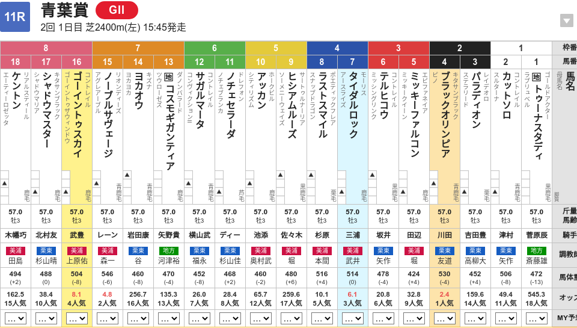

### 【フローラステークス 2026/04/26(日) 】

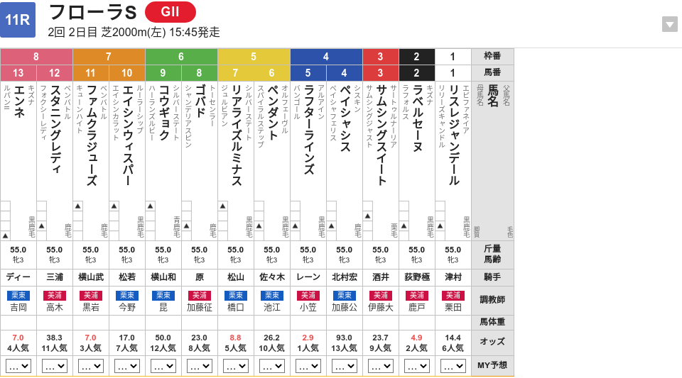

### 【マイラーズカップ 2026/04/26(日) 】

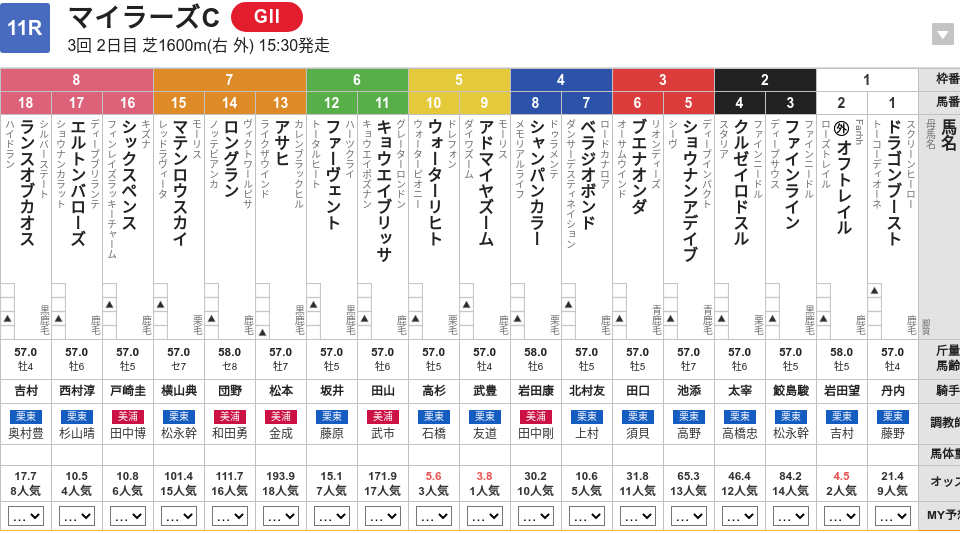

## 4. 単勝予測結果

### 【青葉賞(GⅡ) 2026/04/25(土)】

| 枠番 | 馬番 | 人気 | オッズ | 馬名 | 騎手 | 調教師 | 予測タイム(sec) | 1_順位 | 1-3着内確率(%) | 2_順位 | ﾀﾞｰｸﾎｰｽ確率(%) | 3_順位 |
| --- | --- | --- | --- | --- | --- | --- | --- | --- | --- | --- | --- | --- |
| 1 | 1 | 18 | 545.3 | トゥーナスタディ | 菅原辰徳 | 斎藤雄一 | 152.2 | 14.0 | 4.6 | 16 | 17.3 | 9 |
| 1 | 2 | 11 | 49.4 | カットソロ | 津村明秀 | 矢作芳人 | 152.3 | 16.0 | 9.9 | 14 | 42.8 | 4 |
| 2 | 3 | 14 | 159.6 | パラディオン | 吉田豊 | 高柳大輔 | 151.7 | 10.0 | 11.3 | 12 | 64.8 | 2 |
| 2 | 4 | 1 | 2.4 | ブラックオリンピア | 川田将雅 | 友道康夫 | 143.6 | 1.0 | 38.3 | 1 | 0.7 | 14 |
| 3 | 5 | 9 | 32.8 | ミッキーファルコン | 田辺裕信 | 堀宣行 | 151.8 | 11.0 | 13.7 | 8 | 1.4 | 10 |
| 3 | 6 | 6 | 20.8 | テルヒコウ | 坂井瑠星 | 矢作芳人 | 151.7 | 7.5 | 27.0 | 2 | 0.9 | 13 |
| 4 | 7 | 3 | 6.1 | タイダルロック | 三浦皇成 | 武井亮 | 152.0 | 13.0 | 19.4 | 7 | 0.6 | 18 |
| 4 | 8 | 5 | 10.1 | ラストスマイル | 杉原誠人 | 本間忍 | 151.7 | 7.5 | 25.2 | 4 | 0.7 | 15 |
| 5 | 9 | 17 | 259.6 | ヒシアムルーズ | 佐々木大輔 | 堀宣行 | 151.5 | 4.0 | 10.0 | 13 | 69.6 | 1 |
| 5 | 10 | 12 | 65.7 | アッカン | 池添謙一 | 奥村武 | 152.5 | 18.0 | 12.0 | 11 | 51.8 | 3 |

[output cut: 8 more lines]

### 【フローラステークス(GⅡ) 2026/04/26(日)】

| 枠番 | 馬番 | 人気 | オッズ | 馬名 | 騎手 | 調教師 | 予測タイム(sec) | 1_順位 | 1-3着内確率(%) | 2_順位 | ﾀﾞｰｸﾎｰｽ確率(%) | 3_順位 |
| --- | --- | --- | --- | --- | --- | --- | --- | --- | --- | --- | --- | --- |
| 1 | 1 | 6 | 14.5 | リスレジャンデール | 津村明秀 | 栗田徹 | 128.7 | 9 | 11.3 | 5 | 1.3 | 8 |
| 2 | 2 | 2 | 4.8 | ラベルセーヌ | 荻野極 | 鹿戸雄一 | 126.1 | 2 | 25.4 | 1 | 0.6 | 13 |
| 3 | 3 | 9 | 24.0 | サムシングスイート | 酒井学 | 伊藤大士 | 128.4 | 8 | 6.4 | 9 | 37.0 | 5 |
| 4 | 4 | 13 | 92.9 | ペイシャシス | 北村宏司 | 加藤公太 | 128.3 | 6 | 7.0 | 8 | 59.8 | 2 |
| 4 | 5 | 1 | 2.9 | ラフターラインズ | Ｄ．レーン | 小笠倫弘 | 119.5 | 1 | 15.1 | 4 | 0.7 | 12 |
| 5 | 6 | 10 | 26.0 | ペンダント | 佐々木大輔 | 池江泰寿 | 128.8 | 10 | 4.8 | 13 | 51.2 | 3 |
| 5 | 7 | 5 | 8.9 | リアライズルミナス | 松山弘平 | 橋口慎介 | 128.2 | 4 | 11.0 | 6 | 1.4 | 7 |
| 6 | 8 | 8 | 23.6 | ゴバド | 原優介 | 加藤征弘 | 128.4 | 7 | 4.9 | 12 | 50.2 | 4 |
| 6 | 9 | 12 | 50.4 | コウギョク | 横山和生 | 昆貢 | 129.1 | 12 | 5.1 | 11 | 13.0 | 6 |
| 7 | 10 | 7 | 16.8 | エイシンウィスパー | 松若風馬 | 今野貞一 | 129.0 | 11 | 6.0 | 10 | 0.8 | 11 |

[output cut: 3 more lines]

### 【マイラーズカップ(GⅡ) 2026/04/26(日)】

| 枠番 | 馬番 | 人気 | オッズ | 馬名 | 騎手 | 調教師 | 予測タイム(sec) | 1_順位 | 1-3着内確率(%) | 2_順位 | ﾀﾞｰｸﾎｰｽ確率(%) | 3_順位 |
| --- | --- | --- | --- | --- | --- | --- | --- | --- | --- | --- | --- | --- |
| 1 | 1 | 9 | 21.1 | ドラゴンブースト | 丹内祐次 | 藤野健太 | 98.9 | 12.0 | 6.8 | 12 | 0.8 | 15 |
| 1 | 2 | 2 | 4.4 | オフトレイル | 岩田望来 | 吉村圭司 | 94.8 | 5.0 | 43.1 | 1 | 0.5 | 17 |
| 2 | 3 | 14 | 87.3 | ファインライン | 鮫島克駿 | 松永幹夫 | 98.8 | 11.0 | 2.4 | 16 | 13.1 | 9 |
| 2 | 4 | 12 | 48.8 | クルゼイロドスル | 太宰啓介 | 高橋義忠 | 99.5 | 14.0 | 5.2 | 13 | 31.1 | 3 |
| 3 | 5 | 13 | 66.1 | ショウナンアデイブ | 池添謙一 | 高野友和 | 100.5 | 17.0 | 8.1 | 11 | 33.7 | 2 |
| 3 | 6 | 11 | 32.7 | ブエナオンダ | 田口貫太 | 須貝尚介 | 94.9 | 6.0 | 11.6 | 9 | 34.1 | 1 |
| 4 | 7 | 6 | 10.7 | ベラジオボンド | 北村友一 | 上村洋行 | 91.3 | 2.5 | 23.2 | 3 | 1.0 | 13 |
| 4 | 8 | 10 | 29.4 | シャンパンカラー | 岩田康誠 | 田中剛 | 102.1 | 18.0 | 9.4 | 10 | 18.2 | 5 |
| 5 | 9 | 1 | 3.8 | アドマイヤズーム | 武豊 | 友道康夫 | 91.3 | 2.5 | 12.9 | 8 | 0.5 | 18 |
| 5 | 10 | 3 | 5.8 | ウォーターリヒト | 高杉吏麒 | 石橋守 | 99.7 | 15.0 | 15.6 | 6 | 0.6 | 16 |

[output cut: 8 more lines]

## 5. 人気と着順の乖離率推移

### 【青葉賞_1994y_2019y】

[interactive chart not shown]

### 【フローラステークス_2001y_2019y】

[interactive chart not shown]

### 【マイラーズカップ_1990y_2019y】

[interactive chart not shown]

### 【青葉賞_1994y_2019y】

| No | 開催年 | 不整合率(%) | 頭数 | 人気別着順(1-3位) | 人気別着順(全体) |
| --- | --- | --- | --- | --- | --- |
| 26 | 2019 | 39.3 | 16頭 | 5-1-3 | 5\|1\|3\|6\|9\|12\|16\|14\|4\|10\|8\|2\|15\|11\|13\|7 |
| 25 | 2018 | 40.3 | 18頭 | 6-7-1 | 6\|7\|1\|14\|12\|3\|13\|4\|10\|5\|2\|11\|9\|15\|18\|17\|16\|8 |
| 24 | 2017 | 34.8 | 12頭 | 1-4-8 | 1\|4\|8\|3\|10\|6\|2\|7\|5\|9\|11\|12 |
| 23 | 2016 | 31.1 | 13頭 | 4-5-1 | 4\|5\|1\|2\|3\|10\|9\|7\|8\|6\|12\|11\|13 |
| 22 | 2015 | 33.2 | 18頭 | 1-4-5 | 1\|4\|5\|3\|12\|2\|7\|14\|13\|9\|8\|15\|17\|10\|16\|6\|11\|18 |
| 21 | 2014 | 40.2 | 18頭 | 10-1-4 | 10\|1\|4\|7\|5\|3\|9\|13\|16\|12\|2\|15\|8\|14\|11\|17\|6\|18 |
| 20 | 2013 | 47.0 | 18頭 | 7-9-2 | 7\|9\|2\|4\|10\|12\|5\|8\|6\|15\|1\|3\|14\|11\|13\|18\|16\|17 |
| 19 | 2012 | 35.8 | 17頭 | 1-10-13 | 1\|10\|13\|8\|5\|4\|6\|9\|2\|14\|17\|7\|3\|12\|15\|11\|16 |
| 18 | 2011 | 37.9 | 18頭 | 6-4-1 | 6\|4\|1\|3\|2\|12\|5\|17\|7\|15\|9\|13\|10\|11\|16\|8\|14\|18 |
| 17 | 2010 | 16.2 | 18頭 | 1-2-3 | 1\|2\|3\|12\|8\|5\|14\|11\|16\|13\|10\|6\|4\|9\|17\|7\|15\|18 |

[output cut: 16 more lines]

### 【フローラステークス_2001y_2019y】

| No | 開催年 | 不整合率(%) | 頭数 | 人気別着順(1-3位) | 人気別着順(全体) |
| --- | --- | --- | --- | --- | --- |
| 19 | 2019 | 56.0 | 18頭 | 3-2-9 | 3\|2\|9\|6\|4\|8\|12\|11\|16\|7\|5\|17\|14\|1\|10\|15\|18\|13 |
| 18 | 2018 | 26.5 | 16頭 | 1-13-5 | 1\|13\|5\|2\|12\|8\|4\|11\|16\|14\|7\|15\|9\|3\|6\|10 |
| 17 | 2017 | 40.6 | 18頭 | 12-10-2 | 12\|10\|2\|3\|11\|15\|4\|1\|9\|13\|5\|8\|14\|6\|7\|17\|16\|18 |
| 16 | 2016 | 40.6 | 18頭 | 3-2-13 | 3\|2\|13\|4\|1\|5\|6\|7\|16\|9\|17\|15\|10\|8\|14\|12\|11\|18 |
| 15 | 2015 | 25.0 | 17頭 | 2-1-3 | 2\|1\|3\|12\|8\|10\|5\|11\|13\|4\|7\|14\|15\|9\|6\|16\|17 |
| 14 | 2014 | 31.5 | 18頭 | 4-6-13 | 4\|6\|13\|9\|11\|1\|2\|3\|8\|5\|14\|15\|7\|10\|12\|18\|16\|17 |
| 13 | 2013 | 17.5 | 18頭 | 1-2-9 | 1\|2\|9\|5\|11\|3\|10\|17\|6\|7\|14\|4\|16\|12\|15\|13\|18\|8 |
| 12 | 2012 | 25.2 | 18頭 | 1-2-18 | 1\|2\|18\|10\|7\|4\|9\|16\|14\|11\|8\|17\|13\|12\|5\|3\|15\|6 |
| 11 | 2011 | 58.2 | 17頭 | 9-15-3 | 9\|15\|3\|8\|2\|10\|17\|4\|7\|13\|5\|16\|1\|12\|6\|14\|11 |
| 10 | 2010 | 20.8 | 15頭 | 1-4-2 | 1\|4\|2\|6\|5\|8\|3\|9\|12\|10\|14\|11\|15\|7\|13 |

[output cut: 9 more lines]

### 【マイラーズカップ_1990y_2019y】

| No | 開催年 | 不整合率(%) | 頭数 | 人気別着順(1-3位) | 人気別着順(全体) |
| --- | --- | --- | --- | --- | --- |
| 30 | 2019 | 26.5 | 10頭 | 1-5-4 | 1\|5\|4\|2\|8\|6\|3\|7\|9\|10 |
| 29 | 2018 | 40.2 | 14頭 | 4-2-1 | 4\|2\|1\|11\|10\|8\|3\|7\|6\|13\|14\|5\|12\|9 |
| 28 | 2017 | 23.4 | 11頭 | 2-1-7 | 2\|1\|7\|3\|9\|5\|4\|6\|10\|8\|11 |
| 27 | 2016 | 51.6 | 15頭 | 3-5-11 | 3\|5\|11\|1\|10\|6\|15\|12\|9\|8\|13\|4\|2\|7\|14 |
| 26 | 2015 | 27.5 | 18頭 | 8-5-1 | 8\|5\|1\|6\|2\|11\|3\|7\|15\|13\|9\|10\|14\|17\|16\|18\|4\|12 |
| 25 | 2014 | 28.6 | 16頭 | 3-1-2 | 3\|1\|2\|6\|4\|5\|10\|12\|7\|11\|8\|13\|15\|9\|16\|14 |
| 24 | 2013 | 45.3 | 18頭 | 5-8-3 | 5\|8\|3\|1\|13\|10\|11\|2\|6\|15\|16\|14\|18\|4\|17\|7\|9\|12 |
| 23 | 2012 | 65.8 | 18頭 | 3-6-7 | 3\|6\|7\|17\|8\|10\|5\|2\|16\|14\|9\|15\|11\|4\|12\|13\|18\|1 |
| 22 | 2011 | 43.1 | 18頭 | 7-14-1 | 7\|14\|1\|4\|12\|5\|15\|17\|3\|8\|13\|10\|16\|6\|2\|9\|11\|18 |
| 21 | 2010 | 51.0 | 18頭 | 3-6-5 | 3\|6\|5\|4\|1\|12\|7\|9\|2\|14\|16\|13\|17\|8\|10\|15\|18\|11 |

[output cut: 20 more lines]

## 6. 1-3番人気馬の着順分類予測

### 【青葉賞】

| 分類 | 凡例 | 発生確率(%) | 当該レース | 当該レースランク | 直近1年間 |
| --- | --- | --- | --- | --- | --- |
| 4: 1,2番人気のみ (4_pop12) | 1 \| 2 \| * | 18.0 | 0.96 | 1.29 | 0.00 |
| 1: 1番人気のみ (1_pop1) | 1 \| * \| * | 17.7 | 0.63 | 0.63 | 0.53 |
| 5: 1,3番人気のみ (5_pop13) | 1 \| 3 \| * | 16.8 | 0.77 | 1.03 | 0.50 |
| 8: 1,2,3番人気すべて着外 (8_darkhorse) | * \| * \| * | 13.4 | 2.16 | 1.91 | 0.00 |
| 2: 2番人気のみ (2_pop2) | 2 \| * \| * | 9.5 | 1.53 | 1.36 | 0.00 |
| 6: 2,3番人気のみ (6_pop23) | 2 \| 3 \| * | 8.7 | 1.40 | 0.62 | 0.26 |
| 3: 3番人気のみ (3_pop3) | 3 \| * \| * | 8.6 | 2.77 | 0.92 | 0.00 |
| 7: 1,2,3番人気すべて着内 (7_pop123) | 1 \| 2 \| 3 | 7.2 | 0.77 | 1.53 | 0.00 |

### 【フローラステークス】

| 分類 | 凡例 | 発生確率(%) | 当該レース | 当該レースランク | 直近1年間 |
| --- | --- | --- | --- | --- | --- |
| 4: 1,2番人気のみ (4_pop12) | 1 \| 2 \| * | 18.0 | 1.12 | 1.22 | 0.00 |
| 1: 1番人気のみ (1_pop1) | 1 \| * \| * | 17.7 | 2.21 | 0.72 | 0.35 |
| 5: 1,3番人気のみ (5_pop13) | 1 \| 3 \| * | 16.8 | 1.40 | 1.46 | 0.00 |
| 8: 1,2,3番人気すべて着外 (8_darkhorse) | * \| * \| * | 13.4 | 1.68 | 1.63 | 0.00 |
| 2: 2番人気のみ (2_pop2) | 2 \| * \| * | 9.5 | 2.38 | 1.44 | 0.00 |
| 6: 2,3番人気のみ (6_pop23) | 2 \| 3 \| * | 8.7 | 0.24 | 0.44 | 0.17 |
| 3: 3番人気のみ (3_pop3) | 3 \| * \| * | 8.6 | 0.72 | 0.75 | 0.00 |
| 7: 1,2,3番人気すべて着内 (7_pop123) | 1 \| 2 \| 3 | 7.2 | 1.80 | 2.18 | 0.00 |

### 【マイラーズカップ】

| 分類 | 凡例 | 発生確率(%) | 当該レース | 当該レースランク | 直近1年間 |
| --- | --- | --- | --- | --- | --- |
| 4: 1,2番人気のみ (4_pop12) | 1 \| 2 \| * | 18.1 | 1.30 | 1.22 | 0.00 |
| 1: 1番人気のみ (1_pop1) | 1 \| * \| * | 17.6 | 0.49 | 0.72 | 0.35 |
| 5: 1,3番人気のみ (5_pop13) | 1 \| 3 \| * | 13.7 | 1.23 | 1.19 | 0.00 |
| 8: 1,2,3番人気すべて着外 (8_darkhorse) | * \| * \| * | 13.5 | 1.63 | 1.65 | 0.00 |
| 6: 2,3番人気のみ (6_pop23) | 2 \| 3 \| * | 11.8 | 1.42 | 0.60 | 0.24 |
| 2: 2番人気のみ (2_pop2) | 2 \| * \| * | 9.6 | 1.16 | 1.45 | 0.00 |
| 3: 3番人気のみ (3_pop3) | 3 \| * \| * | 8.6 | 0.77 | 0.75 | 0.00 |
| 7: 1,2,3番人気すべて着内 (7_pop123) | 1 \| 2 \| 3 | 7.2 | 2.57 | 2.18 | 0.00 |

## 7. 3連複予測結果

### 【青葉賞(GⅡ) 2026/04/25(土)】

| 分類 | 馬番 | 枠番 | 人気 | 平均予測タイム(sec) | 1-3着内確率(%) | ﾀﾞｰｸﾎｰｽ確率(%) | 馬名 | 騎手 | 調教師 |
| --- | --- | --- | --- | --- | --- | --- | --- | --- | --- |
| 4: 1,2番人気のみ (4_pop12) | 4-15-6 | 2-7-3 | 1-2-6 | 148.87 | 2.66 | 0.00 | ブラックオリンピア \| ノーブルサヴェージ \| テルヒコウ | 川田将雅 \| Ｄ．レーン \| 坂井瑠星 | 友道康夫 \| 森一誠 \| 矢作芳人 |
| 1: 1番人気のみ (1_pop1) | 4-8-6 | 2-4-3 | 1-5-6 | 149.00 | 2.60 | 0.00 | ブラックオリンピア \| ラストスマイル \| テルヒコウ | 川田将雅 \| 杉原誠人 \| 坂井瑠星 | 友道康夫 \| 本間忍 \| 矢作芳人 |
| 1: 1番人気のみ (1_pop1) | 4-16-6 | 2-8-3 | 1-4-6 | 149.00 | 2.53 | 0.00 | ブラックオリンピア \| ゴーイントゥスカイ \| テルヒコウ | 川田将雅 \| 武豊 \| 坂井瑠星 | 友道康夫 \| 上原佑紀 \| 矢作芳人 |
| 4: 1,2番人気のみ (4_pop12) | 4-15-8 | 2-7-4 | 1-2-5 | 148.87 | 2.49 | 0.00 | ブラックオリンピア \| ノーブルサヴェージ \| ラストスマイル | 川田将雅 \| Ｄ．レーン \| 杉原誠人 | 友道康夫 \| 森一誠 \| 本間忍 |
| 4: 1,2番人気のみ (4_pop12) | 4-15-16 | 2-7-8 | 1-2-4 | 148.87 | 2.42 | 0.00 | ブラックオリンピア \| ノーブルサヴェージ \| ゴーイントゥスカイ | 川田将雅 \| Ｄ．レーン \| 武豊 | 友道康夫 \| 森一誠 \| 上原佑紀 |
| 1: 1番人気のみ (1_pop1) | 4-16-8 | 2-8-4 | 1-4-5 | 149.00 | 2.37 | 0.00 | ブラックオリンピア \| ゴーイントゥスカイ \| ラストスマイル | 川田将雅 \| 武豊 \| 杉原誠人 | 友道康夫 \| 上原佑紀 \| 本間忍 |
| 1: 1番人気のみ (1_pop1) | 4-6-11 | 2-3-6 | 1-6-8 | 149.00 | 2.35 | 0.00 | ブラックオリンピア \| テルヒコウ \| ノチェセラーダ | 川田将雅 \| 坂井瑠星 \| Ｍ．ディー | 友道康夫 \| 矢作芳人 \| 杉山佳明 |
| 4: 1,2番人気のみ (4_pop12) | 4-15-11 | 2-7-6 | 1-2-8 | 148.87 | 2.25 | 0.00 | ブラックオリンピア \| ノーブルサヴェージ \| ノチェセラーダ | 川田将雅 \| Ｄ．レーン \| Ｍ．ディー | 友道康夫 \| 森一誠 \| 杉山佳明 |
| 1: 1番人気のみ (1_pop1) | 4-8-11 | 2-4-6 | 1-5-8 | 149.00 | 2.20 | 0.00 | ブラックオリンピア \| ラストスマイル \| ノチェセラーダ | 川田将雅 \| 杉原誠人 \| Ｍ．ディー | 友道康夫 \| 本間忍 \| 杉山佳明 |
| 1: 1番人気のみ (1_pop1) | 4-16-11 | 2-8-6 | 1-4-8 | 149.00 | 2.14 | 0.00 | ブラックオリンピア \| ゴーイントゥスカイ \| ノチェセラーダ | 川田将雅 \| 武豊 \| Ｍ．ディー | 友道康夫 \| 上原佑紀 \| 杉山佳明 |

[output cut: 806 more lines]

### 【フローラステークス(GⅡ) 2026/04/26(日)】

| 分類 | 馬番 | 枠番 | 人気 | 平均予測タイム(sec) | 1-3着内確率(%) | ﾀﾞｰｸﾎｰｽ確率(%) | 馬名 | 騎手 | 調教師 |
| --- | --- | --- | --- | --- | --- | --- | --- | --- | --- |
| 6: 2,3番人気のみ (6_pop23) | 2-11-13 | 2-7-8 | 2-3-4 | 128.00 | 0.88 | 0.00 | ラベルセーヌ \| ファムクラジューズ \| エンネ | 荻野極 \| 横山武史 \| Ｍ．ディー | 鹿戸雄一 \| 黒岩陽一 \| 吉岡辰弥 |
| 4: 1,2番人気のみ (4_pop12) | 5-2-13 | 4-2-8 | 1-2-4 | 124.60 | 0.85 | 0.00 | ラフターラインズ \| ラベルセーヌ \| エンネ | Ｄ．レーン \| 荻野極 \| Ｍ．ディー | 小笠倫弘 \| 鹿戸雄一 \| 吉岡辰弥 |
| 2: 2番人気のみ (2_pop2) | 2-13-1 | 2-8-1 | 2-4-6 | 127.67 | 0.63 | 0.00 | ラベルセーヌ \| エンネ \| リスレジャンデール | 荻野極 \| Ｍ．ディー \| 津村明秀 | 鹿戸雄一 \| 吉岡辰弥 \| 栗田徹 |
| 2: 2番人気のみ (2_pop2) | 2-13-7 | 2-8-5 | 2-4-5 | 127.50 | 0.62 | 0.00 | ラベルセーヌ \| エンネ \| リアライズルミナス | 荻野極 \| Ｍ．ディー \| 松山弘平 | 鹿戸雄一 \| 吉岡辰弥 \| 橋口慎介 |
| 7: 1,2,3番人気すべて着内 (7_pop123) | 5-2-11 | 4-2-7 | 1-2-3 | 125.10 | 0.60 | 0.00 | ラフターラインズ \| ラベルセーヌ \| ファムクラジューズ | Ｄ．レーン \| 荻野極 \| 横山武史 | 小笠倫弘 \| 鹿戸雄一 \| 黒岩陽一 |
| 2: 2番人気のみ (2_pop2) | 2-13-12 | 2-8-8 | 2-4-11 | 127.37 | 0.54 | 0.00 | ラベルセーヌ \| エンネ \| スタニングレディ | 荻野極 \| Ｍ．ディー \| 三浦皇成 | 鹿戸雄一 \| 吉岡辰弥 \| 高木登 |
| 5: 1,3番人気のみ (5_pop13) | 5-11-13 | 4-7-8 | 1-3-4 | 125.80 | 0.52 | 0.00 | ラフターラインズ \| ファムクラジューズ \| エンネ | Ｄ．レーン \| 横山武史 \| Ｍ．ディー | 小笠倫弘 \| 黒岩陽一 \| 吉岡辰弥 |
| 6: 2,3番人気のみ (6_pop23) | 2-11-1 | 2-7-1 | 2-3-6 | 128.17 | 0.45 | 0.00 | ラベルセーヌ \| ファムクラジューズ \| リスレジャンデール | 荻野極 \| 横山武史 \| 津村明秀 | 鹿戸雄一 \| 黒岩陽一 \| 栗田徹 |
| 6: 2,3番人気のみ (6_pop23) | 2-11-7 | 2-7-5 | 2-3-5 | 128.00 | 0.44 | 0.00 | ラベルセーヌ \| ファムクラジューズ \| リアライズルミナス | 荻野極 \| 横山武史 \| 松山弘平 | 鹿戸雄一 \| 黒岩陽一 \| 橋口慎介 |
| 4: 1,2番人気のみ (4_pop12) | 5-2-1 | 4-2-1 | 1-2-6 | 124.77 | 0.43 | 0.00 | ラフターラインズ \| ラベルセーヌ \| リスレジャンデール | Ｄ．レーン \| 荻野極 \| 津村明秀 | 小笠倫弘 \| 鹿戸雄一 \| 栗田徹 |

[output cut: 276 more lines]

### 【マイラーズカップ(GⅡ) 2026/04/26(日)】

| 分類 | 馬番 | 枠番 | 人気 | 平均予測タイム(sec) | 1-3着内確率(%) | ﾀﾞｰｸﾎｰｽ確率(%) | 馬名 | 騎手 | 調教師 |
| --- | --- | --- | --- | --- | --- | --- | --- | --- | --- |
| 2: 2番人気のみ (2_pop2) | 2-16-7 | 1-8-4 | 2-4-6 | 93.80 | 3.19 | 0.00 | オフトレイル \| シックスペンス \| ベラジオボンド | 岩田望来 \| 戸崎圭太 \| 北村友一 | 吉村圭司 \| 田中博康 \| 上村洋行 |
| 2: 2番人気のみ (2_pop2) | 2-16-17 | 1-8-8 | 2-4-5 | 96.23 | 2.92 | 0.00 | オフトレイル \| シックスペンス \| エルトンバローズ | 岩田望来 \| 戸崎圭太 \| 西村淳也 | 吉村圭司 \| 田中博康 \| 杉山晴紀 |
| 2: 2番人気のみ (2_pop2) | 2-16-18 | 1-8-8 | 2-4-8 | 93.80 | 2.18 | 0.00 | オフトレイル \| シックスペンス \| ランスオブカオス | 岩田望来 \| 戸崎圭太 \| 吉村誠之助 | 吉村圭司 \| 田中博康 \| 奥村豊 |
| 6: 2,3番人気のみ (6_pop23) | 2-10-16 | 1-5-8 | 2-3-4 | 96.60 | 2.14 | 0.00 | オフトレイル \| ウォーターリヒト \| シックスペンス | 岩田望来 \| 高杉吏麒 \| 戸崎圭太 | 吉村圭司 \| 石橋守 \| 田中博康 |
| 2: 2番人気のみ (2_pop2) | 2-17-7 | 1-8-4 | 2-5-6 | 94.90 | 2.11 | 0.00 | オフトレイル \| エルトンバローズ \| ベラジオボンド | 岩田望来 \| 西村淳也 \| 北村友一 | 吉村圭司 \| 杉山晴紀 \| 上村洋行 |
| 2: 2番人気のみ (2_pop2) | 2-16-12 | 1-8-6 | 2-4-7 | 93.80 | 2.10 | 0.00 | オフトレイル \| シックスペンス \| ファーヴェント | 岩田望来 \| 戸崎圭太 \| 坂井瑠星 | 吉村圭司 \| 田中博康 \| 藤原英昭 |
| 4: 1,2番人気のみ (4_pop12) | 9-2-16 | 5-1-8 | 1-2-4 | 93.80 | 1.78 | 0.00 | アドマイヤズーム \| オフトレイル \| シックスペンス | 武豊 \| 岩田望来 \| 戸崎圭太 | 友道康夫 \| 吉村圭司 \| 田中博康 |
| 2: 2番人気のみ (2_pop2) | 2-16-6 | 1-8-3 | 2-4-11 | 95.00 | 1.59 | 0.00 | オフトレイル \| シックスペンス \| ブエナオンダ | 岩田望来 \| 戸崎圭太 \| 田口貫太 | 吉村圭司 \| 田中博康 \| 須貝尚介 |
| 2: 2番人気のみ (2_pop2) | 2-7-18 | 1-4-8 | 2-6-8 | 92.47 | 1.58 | 0.00 | オフトレイル \| ベラジオボンド \| ランスオブカオス | 岩田望来 \| 北村友一 \| 吉村誠之助 | 吉村圭司 \| 上村洋行 \| 奥村豊 |
| 8: 1,2,3番人気すべて着外 (8_darkhorse) | 16-17-7 | 8-8-4 | 4-5-6 | 95.07 | 1.57 | 0.00 | シックスペンス \| エルトンバローズ \| ベラジオボンド | 戸崎圭太 \| 西村淳也 \| 北村友一 | 田中博康 \| 杉山晴紀 \| 上村洋行 |

[output cut: 806 more lines]

## 8. 直近の全レース情報

[output not shown]

[output cut: 8 more lines]